# Buoy Observations of Air And Sea Temperatures in The Southern Bering Sea

3/18/2018

## Background

Global warming has been a hotly debated topic for many years. In order to explore this issue, 32 years of air and sea temperature taken from a buoy in the southern Bering Sea were examined. The data were taken from the National Data Buoy Center.

## Data Selection

- Data on air and sea temperatures used in this analysis come from NOAA Weather Station buoy 46035 at 57.026 N 177.738 W in the NOAA National Data Buoy Center and it covers the time period from 1985 to 2017. However, data in 2012 and 2013 are completely missing.
- The majority part of the analysis is based on temperature data recorded at noon.
  - Note that methods of recording data change over time so we adjusted our methods of data selection accordingly
    - for data before 2009: we selected temperatures recorded exactly at noon (ie. 12:00 PM)
    - for data in/after 2009: we selected temperatures recorded slightly before noon (ie. 11:50 AM)

## Air Temperature

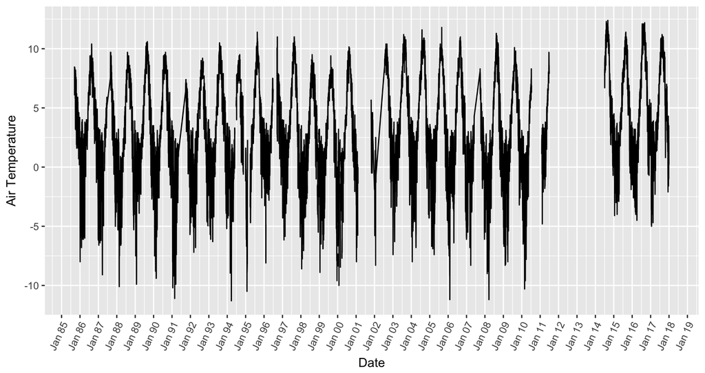

- There is a seasonal pattern repeating every year, and the air temperature is generally between -10ºC and 10ºC.

## Has the mean air temperature changed over the past 30 years?

- We used the mean air temperature every year to conduct a one-way ANOVA test to see if it changes over time.

\[H_{0}: \mu_{1985} = \mu_{1986} = \mu_{1987} = ... = \mu_{2017}\] \[H_{a}: At\ least\ one\ \mu_i\ is\ different\]

```
##
##  One-way analysis of means (not assuming equal variances)
##
## data:  ATMP and Year
## F = 31.853, num df = 30.0, denom df = 2773.4, p-value < 2.2e-16
```

- With a significance level of \(\alpha=0.05\), the result of the test suggests that there is a statistically significant change in mean air temperature in the past 30 years.
- *Note: We conducted this one-way test not assuming equal variances, and this condition is assumed for all one-way tests in the following sections.*

## Sea Temperature

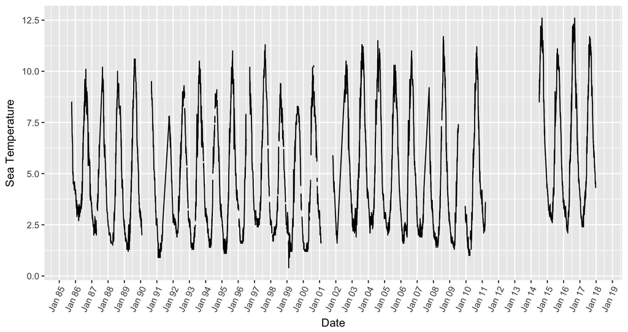

- There is a seasonal pattern repeating every year, and the sea temperature is generally always above 0ºC.

## Has the mean sea temperature changed over the past 30 years?

- We used the mean sea temperature every year to conduct a one-way ANOVA test to see if it changes over time.

\[H_{0}: \mu_{1985} = \mu_{1986} = \mu_{1987} = ... = \mu_{2017}\] \[H_{a}: At\ least\ one\ \mu_i\ is\ different\]

```
##
##  One-way analysis of means (not assuming equal variances)
##
## data:  WTMP and Year
## F = 97.352, num df = 30.0, denom df = 2600.8, p-value < 2.2e-16
```

- With a significance level of \(\alpha=0.05\), the result of the test suggests that there is a statistically significant change in mean sea temperature in the past 30 years.

## Relationship Between Air Temperature and Sea Temperature

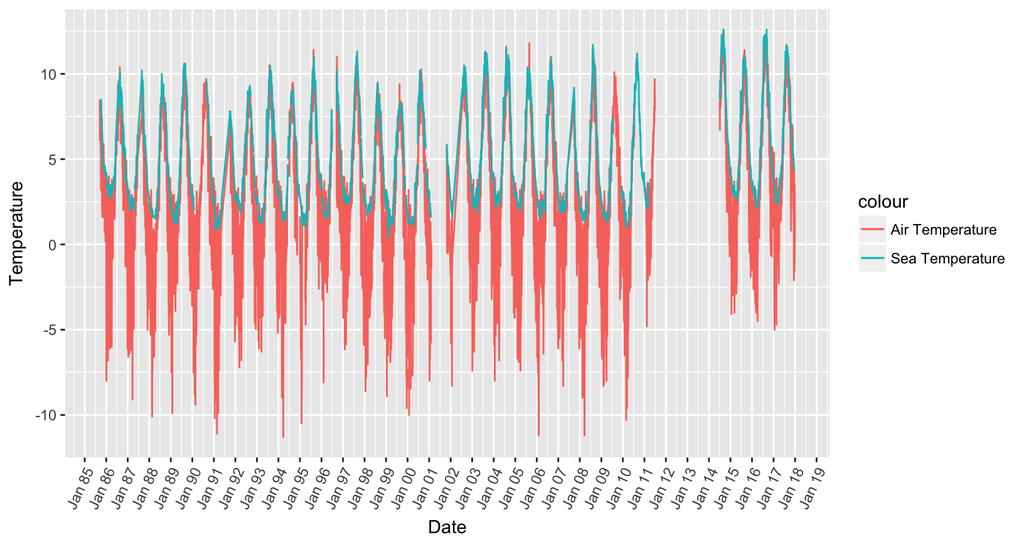

## Relationship Between Air and Sea Temperatures (cont.)

- The previous plot shows that air and sea temperatures are highly correlated, as they both follow a very similar pattern over time. In addition, the sea temperature is always above 0ºC and is generally higher than the air temperature each day.
- A further check for the correlation between two variables with the following code yields the result of 0.8733613, which is very high and confirms our findings from the plot.

  `cor(tidy$ATMP, tidy$WTMP, use = 'complete.obs')`

## Issue with Missing Data

- The dataset contains a lot of missing values. For example, there is no data available at all for 2013, and even if there exists a table for observations in 2012, no values were recorded in it.
- Besides these two special cases, missing values for the air temperature and the sea temperature are also present in the data for other years.

## Issue with Sampling Method

- Due to the nature of the sampled data (ie. only one observation per day at noon), it can be possible that the temperatures we are using are higher because the sun is almost above the buoy at noon time. If we had picked the observations at night, the temperatures would probably be lower.
- We tried to improve our sampling method by analyzing all data provided by the website instead of selecting only one observation for each day.
- In order to check if including all data would change the result of the analysis, we conducted one-way ANOVA tests for both air and sea temperatures.

## Issue with Sampling Method (cont.)

**Does a change in the sampling method lead to a different result?**

- Air temperature

\[H_{0}: \mu_{1985} = \mu_{1986} = \mu_{1987} = ... = \mu_{2017}\] \[H_{a}: At\ least\ one\ \mu_i\ is\ different\]

```
##
##  One-way analysis of means (not assuming equal variances)
##
## data:  ATMP and Year
## F = 780.8, num df = 30, denom df = 66512, p-value < 2.2e-16
```

- With a significance level of \(\alpha=0.05\), and a p-value < 2.2e-16, the result of the test suggests that even with all data provided on the website, there is still a statistically significant change in mean air temperature in the past 30 years.

## Issue with Sampling Method (cont.)

**Does a change in the sampling method lead to a different result?**

- Sea temperature

\[H_{0}: \mu_{1985} = \mu_{1986} = \mu_{1987} = ... = \mu_{2017}\] \[H_{a}: At\ least\ one\ \mu_i\ is\ different\]

```
##
##  One-way analysis of means (not assuming equal variances)
##
## data:  WTMP and Year
## F = 2372.3, num df = 30, denom df = 62772, p-value < 2.2e-16
```

- With a significance level of \(\alpha=0.05\), and a p-value < 2.2e-16, the result of the test suggests that even with all data provided on the website, there is still a statistically significant change in mean sea temperature in the past 30 years.